# Defunciones de pacientes con esquema de vacunación completo y efectivo

Actualizado el 21 de septiembre del 2021 con datos de la SINAVE

# Análisis descriptivo

Con respecto a la base de datos de la SINAVE, al día de hoy se registran 1050 casos positivos a COVID-19 de pacientes que contaban con un esquema de vacunación completo y a su vez efectivo. De estos, 152 fallecieron, lo que representa el 14% de los casos.

### Edad

El rango de edad de las defunciones es de 34 a 94 años. Por otro lado, la edad promedio de los 152 pacientes que fallecieron es de 71 años.

### Tipo de paciente

De los pacientes que fallecieron, el 100% requirieron de hospitalización.

### Laboratorio de la vacuna

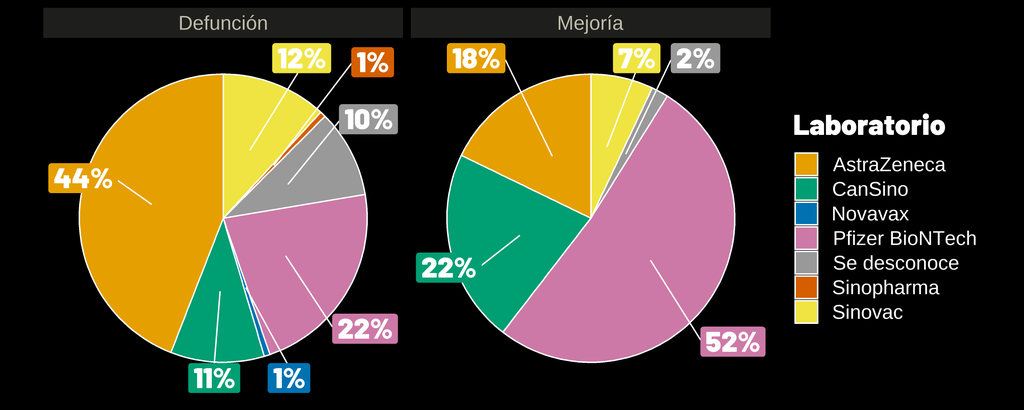

### Comorbilidades

En el siguiente gráfico se puede apreciar el número de condiciones preexistentes o comorbilidades que presentaban en general los pacientes que fallecieron. El 13% no padece de alguna comorbilidad; 80% padece entre 1 y 3 comorbilidades y 7% padece 4 o más.

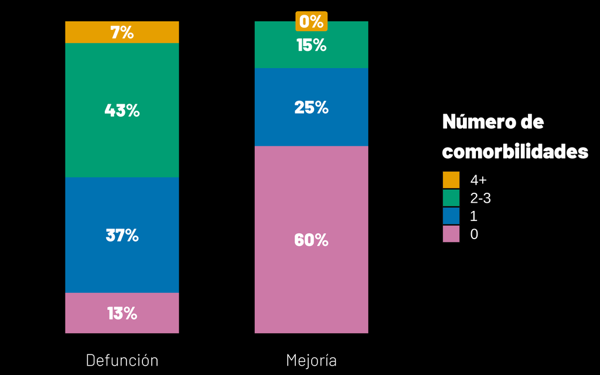

Las tres principales comorbilidades de las que padecían estos pacientes eran HIPERTEN, DIABETES y OBESIDAD, con una incidencia del 60%, 43% y 24% respectivamente.

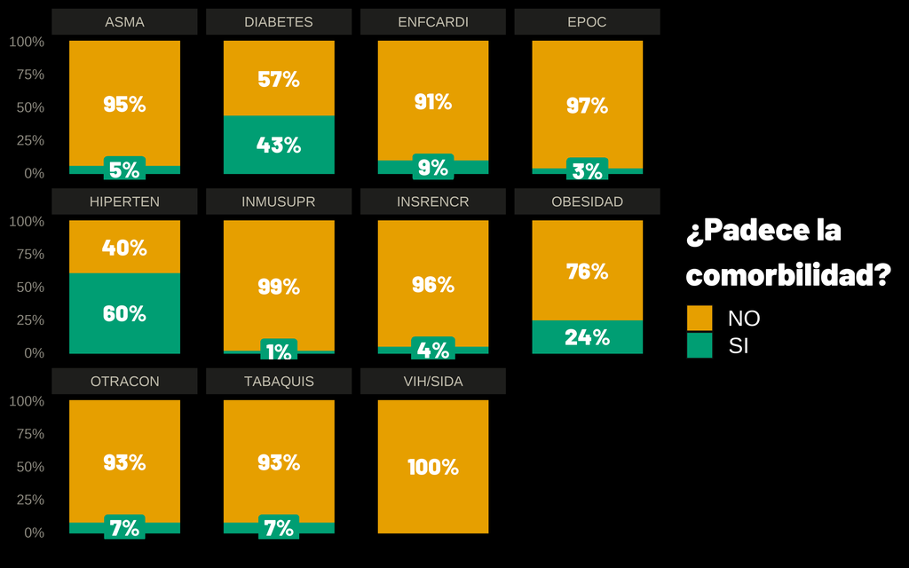